# Final Presentation

December 19, 2018

## Introduction

- This dataset is predicting whether a pitch on the TV Show Shark Tank gets a deal or not
- Helpful to those wishing to go on Shark Tank
- The target variable is "deal", which either true or false.
- Dataset found on Kaggle, added some columns to analyze data
- 22 Variables- most important are the "Asked for" and "Exchanged stake"

## Input Variables

- Name and Description of Product/Service, Category it is in, Website
- Episode/ Season, Air Date
- Entreprenuers Names, Location, Multiple or Not
- $ Asked For, Percent Equity Offered, Valuation of Company
- Sharks Present for Episode

## Input Dataset

```r
ST = read.csv("C:/Users/student/Documents/Senior Year/Programming with R/FinalDataset.csv")
library(caret)
```

```r
library(ggplot2)
```

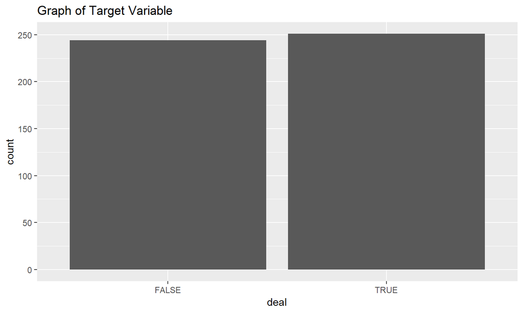

```r
library(ggplot2)
ggplot(data = ST) + geom_bar(mapping = aes(x = deal), position = "dodge") + ggtitle("Graph of Target Variable") + labs(fill = "True or False")
```

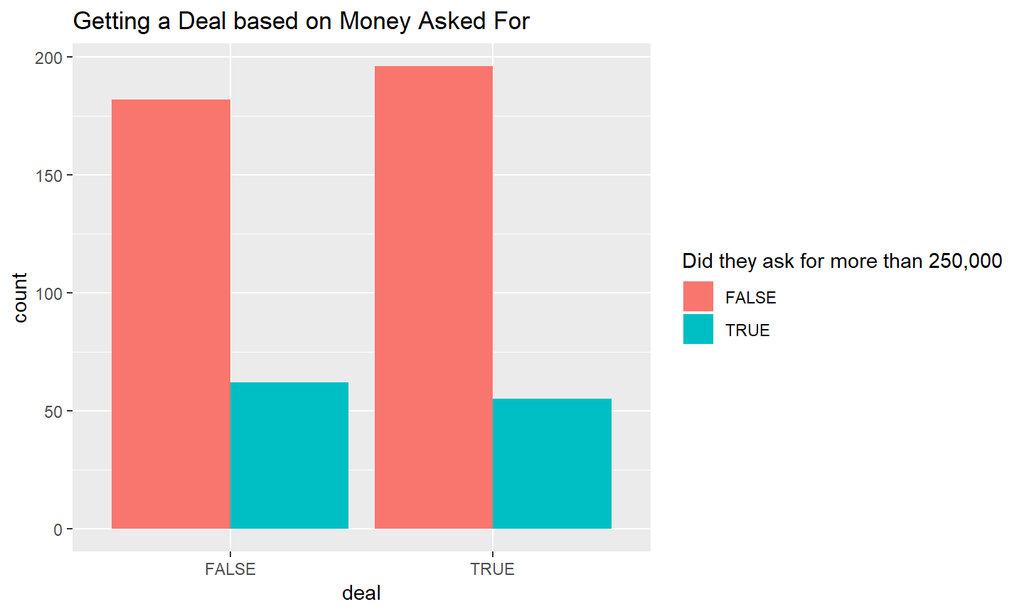

```r
ggplot(data = ST) + geom_bar(mapping = aes(x = deal, fill = AboveAvg), position = "dodge") + ggtitle("Getting a Deal based on Money Asked For") + labs(fill = "Did they ask for more than 250,000")
```

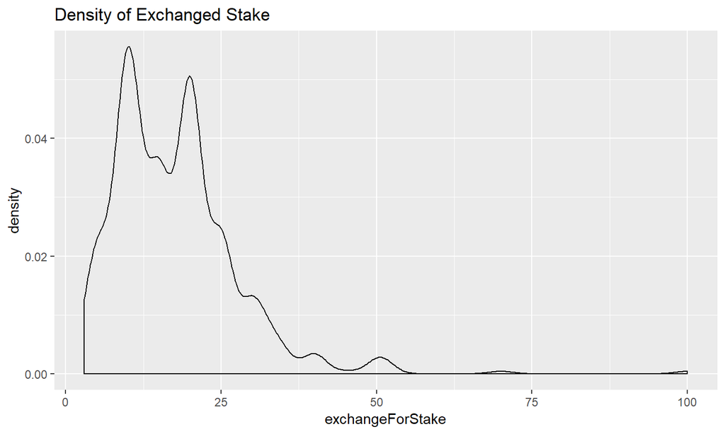

```r
ggplot(data = ST) + geom_density(mapping = aes(x = exchangeForStake)) + ggtitle("Density of Exchanged Stake")
```

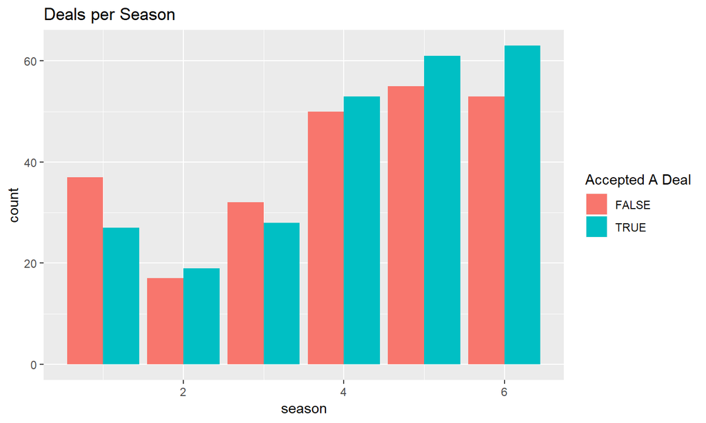

```r
ggplot(data = ST) + geom_bar(mapping = aes(x = season, fill = deal), position = "dodge") + ggtitle("Deals per Season") + labs(fill = "Accepted A Deal")
```

## Comparing Imputation Methods

splitIndex <- createDataPartition(ST$deal, p = .70, list = FALSE, times = 1) train <- ST[splitIndex,] test <- ST[-splitIndex,]

## Results of Confusion Matrix

-Accuracy : 0.473 -95% CI : (0.3904, 0.5566)

## Recoding categorical variables

```r
levels(ST$category) <- c("Food", "Outdoors", "Childrens", "Childrens", "Childrens", "Childrens", "Childrens", "Other", "Fashion", "Fitness", "Other", "Tech", "Tech", "Fashion", "Fitness", "Fitness", "Fitness", "Home", "Outdoors", "Fitness", "Other", "Other", "Home", "Home", "Home", "Home", "Home", "Fashion", "Fashion", "Fashion", "Fashion", "Fashion", "Tech", "Other", "Food", "Other", "Tech", "Outdoors", "Other", "Fashion", "Home", "Home", "Tech", "Other", "Food", "Home", "Childrens", "Fashion", "Food", "Other", "Food", "Fashion", "Fashion", "Fashion")
```

## Predictive Models

## Forest Model

Grid1 = expand.grid(mtry = c(1:2), splitrule = c("gini"), min.node.size = c(1:2))

forest_ST_tuned <- train(deal ~.,data = ST, method = "ranger", trControl = trainControl(method ="cv", number = 7, verboseIter = TRUE), tuneGrid = Grid1) forest_ST_tuned

Accuracy : .507071

## Decision Tree Model

dtree_ST_tuned <- train(deal ~.,data = ST, method = "rpart", trControl = trainControl(method ="cv", number = 10, verboseIter = TRUE)) dtree_ST_tuned

Accuracy : 0.5277119  
cp : 0.01844262

## Confusion Matrix Model

splitIndex <- createDataPartition(ST$deal, p = .70, list = FALSE, times = 1) train <- ST[splitIndex,] test <- ST[-splitIndex,]

Accuracy : 0.5338

## GLMnet Model

Grid2 = expand.grid(.alpha=0:1,.lambda=seq(0.001,1,length=10))